# In-depth CSFLA parameter tuning

The methodology remains the same as with the preliminary tuning:

First, we isolate each parameter to test its influence on performance results and try to extract knowledge from it in the first part, 'parametric analysis'.

We then try to find some good combinations of these attributes in the second part, 'combinatorial analysis'.

Finally, we test the combinations, tune the most performing, and choose a final PSO configuration which we will use as the final product and use for the testing data.

## I. Parametric analysis

```python
# Libraries and helper functions
import pickle
import json
import sys
import pandas as pd
%matplotlib inline
import matplotlib.pyplot as plt
import seaborn as sns
import numpy as np

from toolz import get_config, get_all_config_results

def plot_configs(df):
    plt.plot(df.loc['value'], label='fitness')
    plt.plot(df.loc['mdd'])
    plt.plot(df.loc['ret'], label='return')
    plt.xticks(rotation=20)
    plt.xlabel('Configurations', size=14)
    plt.ylabel('Value', size=14)
    plt.title("Average fitness value on test months for 4 currency pairs")
    plt.legend()
    plt.show()
```

```python
cfg = get_config(file='../config/training_config.json')
df = get_all_config_results(cfg, '../config/algos/csfla_param_exp_configs.json')
mean_by_config = pd.pivot_table(df, values=['value', 'mdd', 'no_of_transactions', 'realised_profit', 'ret', 'wealth'], columns=['config name'], aggfunc=np.mean)
mean_by_config
```

| config name | csfla reference | even lower generations | extreme niching 1 | extreme niching 2 | extreme niching 3 | extreme niching expensive | extreme niching expensive 4 | extreme niching expensive 5 | extreme niching expensive l6 | extreme niching expensive low gen | ... | low scaled highest n frogs | low sub generations | medium generations | medium n frogs | medium n memeplexes | medium n sm frogs | medium sub generations | minimum generations | very high sub generations | very low generations |
| --- | --- | --- | --- | --- | --- | --- | --- | --- | --- | --- | --- | --- | --- | --- | --- | --- | --- | --- | --- | --- | --- |
| mdd | 0.000449 | 0.000453 | 0.000664 | 0.000845 | 0.000769 | 0.000385 | 0.000795 | 0.000762 | 0.000755 | 0.000789 | ... | 0.000399 | 0.000380 | 0.000450 | 0.000399 | 0.000400 | 0.000488 | 0.000415 | 0.000534 | 0.000403 | 0.000472 |
| no_of_transactions | 24.455093 | 23.715046 | 19.986343 | 18.965278 | 23.076488 | 22.111111 | 22.160417 | 21.362037 | 20.380556 | 21.413889 | ... | 23.168519 | 21.591204 | 22.385053 | 22.828704 | 24.112037 | 22.381481 | 19.611343 | 21.479630 | 23.286111 | 23.191667 |
| realised_profit | 0.495965 | 0.770835 | 1.455586 | 1.503166 | 1.070007 | 0.679716 | 1.598367 | 1.248551 | 1.252492 | 1.523377 | ... | 0.380954 | 0.374977 | 0.571473 | 0.607538 | 0.650197 | 0.534128 | 0.403155 | 0.661957 | 0.459547 | 0.821022 |
| ret | 0.000099 | 0.000154 | 0.000291 | 0.000301 | 0.000214 | 0.000136 | 0.000320 | 0.000250 | 0.000250 | 0.000305 | ... | 0.000076 | 0.000075 | 0.000114 | 0.000122 | 0.000130 | 0.000107 | 0.000081 | 0.000132 | 0.000092 | 0.000164 |
| value | 0.000009 | 0.000064 | 0.000158 | 0.000132 | 0.000060 | 0.000059 | 0.000161 | 0.000097 | 0.000099 | 0.000147 | ... | -0.000004 | -0.000001 | 0.000024 | 0.000042 | 0.000050 | 0.000009 | -0.000002 | 0.000026 | 0.000011 | 0.000070 |
| wealth | 500000.495965 | 500000.770835 | 500001.455586 | 500001.503166 | 500001.070007 | 500000.679716 | 500001.598367 | 500001.248551 | 500001.252492 | 500001.523377 | ... | 500000.380954 | 500000.374977 | 500000.571473 | 500000.607538 | 500000.650197 | 500000.534128 | 500000.403155 | 500000.661957 | 500000.459547 | 500000.821022 |

6 rows × 41 columns

## N Frogs

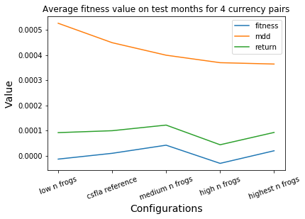

```python
plot_configs(mean_by_config[['low n frogs', 'csfla reference', 'medium n frogs', 'high n frogs', 'highest n frogs']])
```

I think that what happens here is that when we increase the number of frogs (from low to medium) we get an increase in fitness because we can explore better the search space, but when the number of frogs gets too high, we have a decrease of fitness because the more the frogs, the less likely a high performance frog has the chance to be selected for evolution, so we have less evolved frogs and thus lower fitness.

## N memeplexes

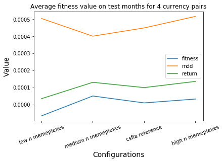

```python
plot_configs(mean_by_config[['low n memeplexes',  'medium n memeplexes', 'csfla reference', 'high n memeplexes']])
```

## Number of frogs selected for sub-memeplex

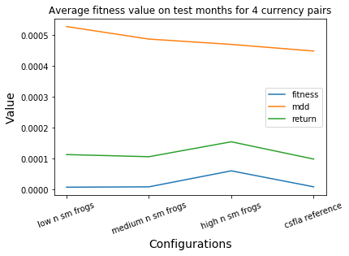

```python
plot_configs(mean_by_config[['low n sm frogs',  'medium n sm frogs','high n sm frogs', 'csfla reference']])
```

## Number of generations

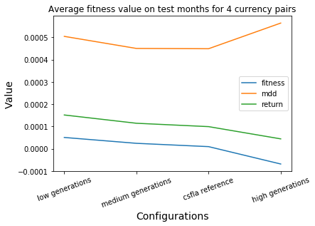

```python
plot_configs(mean_by_config[['low generations', 'medium generations', 'csfla reference', 'high generations']])
```

This is interesting, it's the opposite of what I expected. Maybe this means that csfla is able to generate good initial candidates with only a bit of evolution, and that it's a bad optimizer over time. Maybe we could use the csfla as a meta-metaheuristic for the pso, so we give good inital candidates to the pso which evolves it on the optimum.

## Number of sub-memeplex generations

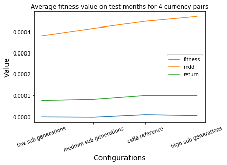

```python
plot_configs(mean_by_config[['low sub generations', 'medium sub generations', 'csfla reference', 'high sub generations']])
```

The higher the number of sub-generations, the more the generations will be optimized. I could try and increase even more the number of sub generations

## Round 2

Before jumping to conclusions, I try to push the number of sub-memeplex generations, by creating additionnal configs with higher sub generations.

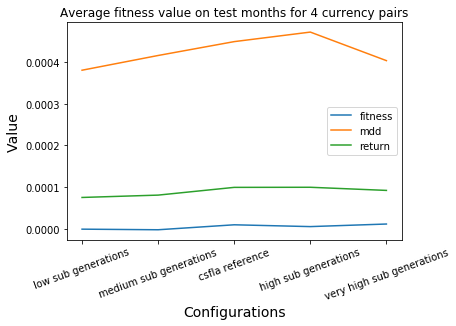

```python
plot_configs(mean_by_config[['low sub generations', 'medium sub generations', 'csfla reference', 'high sub generations', 'very high sub generations']])
```

```python
mean_by_config[['low sub generations', 'medium sub generations', 'csfla reference', 'high sub generations', 'very high sub generations']]
```

| config name | low sub generations | medium sub generations | csfla reference | high sub generations | very high sub generations |
| --- | --- | --- | --- | --- | --- |
| mdd | 0.000380 | 0.000415 | 0.000449 | 0.000472 | 0.000403 |
| no_of_transactions | 21.591204 | 19.611343 | 24.455093 | 22.192593 | 23.286111 |
| realised_profit | 0.374977 | 0.403155 | 0.495965 | 0.497140 | 0.459547 |
| ret | 0.000075 | 0.000081 | 0.000099 | 0.000099 | 0.000092 |
| value | -0.000001 | -0.000002 | 0.000009 | 0.000005 | 0.000011 |
| wealth | 500000.374977 | 500000.403155 | 500000.495965 | 500000.497140 | 500000.459547 |

It seems that increasing the number of sub generations is a good idea, even though we loose a bit of return we decrease mdd so the overall fitness increases with the number of sub generations. However execution seemed much more slow (which makes sense)

At this point, my intuition for this algorithm is that by increasing capacity (number of frogs), you can increase fitness, as long as you keep increasing the chance for the frogs to be more performing.

It seems that regardless of capacity increasing the number of sub generations is a good idea because the algorithm is shuffling/stochastic enough to avoid overfitting on optimums.

It looks as if when we increase the number of generations, we can mix up the local optimums too much (the frogs jump around too much). To confirm this I run the algorithm with some even lower values of generation numbers. If I'm correct we should have higher fitness for lower number of generations but if the number of generations is too low (say, only one generation), we could loose the frog-leaping aspect and thus loose the benefit of exchanging information between optimums. However, if we have a higher fitness even with 1 generation, it could indicate that exchanging information between optimums is irrelevant for our problem (which could explain why pso rush strategy performs well for example), that the optimums are too seperate/different from one another. This could give us valuable insight towards the problem

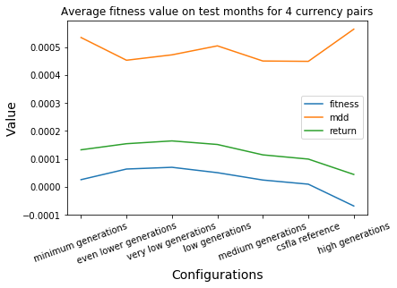

```python
plot_configs(mean_by_config[['minimum generations', 'even lower generations', 'very low generations' , 'low generations', 'medium generations', 'csfla reference', 'high generations']])
```

```python
mean_by_config[['minimum generations', 'even lower generations', 'very low generations' , 'low generations', 'medium generations', 'csfla reference', 'high generations']]
```

| config name | minimum generations | even lower generations | very low generations | low generations | medium generations | csfla reference | high generations |
| --- | --- | --- | --- | --- | --- | --- | --- |
| mdd | 0.000534 | 0.000453 | 0.000472 | 0.000504 | 0.000450 | 0.000449 | 0.000564 |
| no_of_transactions | 21.479630 | 23.715046 | 23.191667 | 20.297222 | 22.385053 | 24.455093 | 24.247685 |
| realised_profit | 0.661957 | 0.770835 | 0.821022 | 0.757194 | 0.571473 | 0.495965 | 0.221359 |
| ret | 0.000132 | 0.000154 | 0.000164 | 0.000151 | 0.000114 | 0.000099 | 0.000044 |
| value | 0.000026 | 0.000064 | 0.000070 | 0.000051 | 0.000024 | 0.000009 | -0.000068 |
| wealth | 500000.661957 | 500000.770835 | 500000.821022 | 500000.757194 | 500000.571473 | 500000.495965 | 500000.221359 |

It looks like our hypothesis was only partly true: it's still a good idea to exchange a little amout of information between the optimums.

As a result of this analysis, I would like to test if we can get an increase of fitness if we increase the number of frogs while proportionnaly increasing the number of memeplexes.

```python
mean_by_config[['low scaled high n frogs', 'high scaled high n frogs', 'low scaled highest n frogs ',  "high scaled highest n frogs "]]
```

| config name | low scaled high n frogs | high scaled high n frogs | low scaled highest n frogs | high scaled highest n frogs |
| --- | --- | --- | --- | --- |
| mdd | 0.000396 | 0.000388 | 0.000399 | 0.000388 |
| no_of_transactions | 24.762963 | 23.920370 | 23.168519 | 23.920370 |
| realised_profit | 0.368050 | 0.539773 | 0.380954 | 0.539773 |
| ret | 0.000074 | 0.000108 | 0.000076 | 0.000108 |
| value | -0.000006 | 0.000030 | -0.000004 | 0.000030 |
| wealth | 500000.368050 | 500000.539773 | 500000.380954 | 500000.539773 |

This is very interesting, it seems like the number of frogs doesn't really matter, that it's rather the number of frogs in the sub memeplexes that count.

The low scaled configurations have the same number of frogs (60 for high, and 100 for highest), high number of memeplexes (so you'd expect them to explore more optimums), but lower number of frogs per sub meme plexes.

Also higher number of frogs does not mean higher fitness (same results in high scaled configs). So in our proposed configurations we can take this into account to have cheaper and still effective configurations.

# 2. Combinatorial Analysis

First, I test out the configs of my preliminary experiment on this new training data:

```python
mean_by_config[["extreme niching expensive", "global cheap", "global expensive"]]
```

| config name | extreme niching expensive | global cheap | global expensive |
| --- | --- | --- | --- |
| mdd | 0.000385 | 0.000373 | 0.000508 |
| no_of_transactions | 22.111111 | 20.618717 | 22.475926 |
| realised_profit | 0.679716 | 0.276358 | 0.285408 |
| ret | 0.000136 | 0.000055 | 0.000057 |
| value | 0.000059 | -0.000019 | -0.000045 |
| wealth | 500000.679716 | 500000.276358 | 500000.285408 |

It's interesting to see that global cheap and global expensive did not do very well, so i'm grateful for this second round of analysis! Extreme niching yields correct results, I'll try to map my next configurations based on it.

## Recap

The best performing configurations so far are:

```python
mean_by_config.sort_values('value', axis=1)
```

| config name | high generations | low n memeplexes | global expensive | high n frogs | global cheap | low n frogs | low scaled high n frogs | low scaled highest n frogs | medium sub generations | low sub generations | ... | very low generations | low gen high scaled | extreme niching expensive 5 | extreme niching expensive l6 | extreme niching expensive lower gen | extreme niching 2 | extreme niching expensive med gen 1 | extreme niching expensive low gen | extreme niching 1 | extreme niching expensive 4 |
| --- | --- | --- | --- | --- | --- | --- | --- | --- | --- | --- | --- | --- | --- | --- | --- | --- | --- | --- | --- | --- | --- |
| mdd | 0.000564 | 0.000504 | 0.000508 | 0.000369 | 0.000373 | 0.000526 | 0.000396 | 0.000399 | 0.000415 | 0.000380 | ... | 0.000472 | 0.000626 | 0.000762 | 0.000755 | 0.000765 | 0.000845 | 0.000746 | 0.000789 | 0.000664 | 0.000795 |
| no_of_transactions | 24.247685 | 25.499074 | 22.475926 | 22.865741 | 20.618717 | 23.248148 | 24.762963 | 23.168519 | 19.611343 | 21.591204 | ... | 23.191667 | 23.410185 | 21.362037 | 20.380556 | 23.393585 | 18.965278 | 23.258995 | 21.413889 | 19.986343 | 22.160417 |
| realised_profit | 0.221359 | 0.171108 | 0.285408 | 0.216884 | 0.276358 | 0.458005 | 0.368050 | 0.380954 | 0.403155 | 0.374977 | ... | 0.821022 | 1.007595 | 1.248551 | 1.252492 | 1.406630 | 1.503166 | 1.438550 | 1.523377 | 1.455586 | 1.598367 |
| ret | 0.000044 | 0.000034 | 0.000057 | 0.000043 | 0.000055 | 0.000092 | 0.000074 | 0.000076 | 0.000081 | 0.000075 | ... | 0.000164 | 0.000202 | 0.000250 | 0.000250 | 0.000281 | 0.000301 | 0.000288 | 0.000305 | 0.000291 | 0.000320 |
| value | -0.000068 | -0.000067 | -0.000045 | -0.000030 | -0.000019 | -0.000014 | -0.000006 | -0.000004 | -0.000002 | -0.000001 | ... | 0.000070 | 0.000076 | 0.000097 | 0.000099 | 0.000128 | 0.000132 | 0.000139 | 0.000147 | 0.000158 | 0.000161 |
| wealth | 500000.221359 | 500000.171108 | 500000.285408 | 500000.216884 | 500000.276358 | 500000.458005 | 500000.368050 | 500000.380954 | 500000.403155 | 500000.374977 | ... | 500000.821022 | 500001.007595 | 500001.248551 | 500001.252492 | 500001.406630 | 500001.503166 | 500001.438550 | 500001.523377 | 500001.455586 | 500001.598367 |

6 rows × 41 columns

So it seems that we want:

- Low generations
- A good ratio of frogs per sub memeplex
- High sub generations

I take the 'very low generations' config and increase the number of sm frogs in a couple of configs

```python
mean_by_config[["low gens high sub gens", "low gens higher sub gens", "low gen high scaled", "low gen high scaled high sub gens", "extreme niching expensive low gen"]]
```

| config name | low gens high sub gens | low gens higher sub gens | low gen high scaled | low gen high scaled high sub gens | extreme niching expensive low gen |
| --- | --- | --- | --- | --- | --- |
| mdd | 0.000518 | 0.000526 | 0.000626 | 0.000646 | 0.000789 |
| no_of_transactions | 26.304167 | 22.385913 | 23.410185 | 24.597222 | 21.413889 |
| realised_profit | 0.774314 | 0.583967 | 1.007595 | 0.960941 | 1.523377 |
| ret | 0.000155 | 0.000117 | 0.000202 | 0.000192 | 0.000305 |
| value | 0.000051 | 0.000012 | 0.000076 | 0.000063 | 0.000147 |
| wealth | 500000.774314 | 500000.583967 | 500001.007595 | 500000.960941 | 500001.523377 |

```python
mean_by_config[['extreme niching expensive lower gen', "extreme niching expensive med gen 1", "extreme niching 1", "extreme niching 2", "extreme niching 3","extreme niching expensive 4", "extreme niching expensive 5", "extreme niching expensive l6"]]
```

| config name | extreme niching expensive lower gen | extreme niching expensive med gen 1 | extreme niching 1 | extreme niching 2 | extreme niching 3 | extreme niching expensive 4 | extreme niching expensive 5 | extreme niching expensive l6 |
| --- | --- | --- | --- | --- | --- | --- | --- | --- |
| mdd | 0.000765 | 0.000746 | 0.000664 | 0.000845 | 0.000769 | 0.000795 | 0.000762 | 0.000755 |
| no_of_transactions | 23.393585 | 23.258995 | 19.986343 | 18.965278 | 23.076488 | 22.160417 | 21.362037 | 20.380556 |
| realised_profit | 1.406630 | 1.438550 | 1.455586 | 1.503166 | 1.070007 | 1.598367 | 1.248551 | 1.252492 |
| ret | 0.000281 | 0.000288 | 0.000291 | 0.000301 | 0.000214 | 0.000320 | 0.000250 | 0.000250 |
| value | 0.000128 | 0.000139 | 0.000158 | 0.000132 | 0.000060 | 0.000161 | 0.000097 | 0.000099 |
| wealth | 500001.406630 | 500001.438550 | 500001.455586 | 500001.503166 | 500001.070007 | 500001.598367 | 500001.248551 | 500001.252492 |

These results are very promising! I could try and push the extreme niching expensive strategy further.

## Friedman test

Export to file to friedman test

```python
# Load all the data
df = get_all_config_results(cfg, '../config/algos/csfla_param_exp_configs.json')
df2 = get_all_config_results(cfg, '../config/algos/csfla_params_config_2.json')
df3 = get_all_config_results(cfg, '../config/algos/csfla_configs.json')
all_configs = pd.concat([df, df2, df3])
```

```python
all_meaned_configs = pd.pivot_table(all_configs, values=['value', 'mdd', 'no_of_transactions', 'realised_profit', 'ret', 'wealth'], columns=['config name'], aggfunc=np.mean)
all_meaned_configs.sort_values('value', axis=1)
```

| config name | high generations | low n memeplexes | global expensive | high n frogs | global cheap | low n frogs | low scaled high n frogs | low scaled highest n frogs | medium sub generations | low sub generations | ... | very low generations | low gen high scaled | extreme niching expensive 5 | extreme niching expensive l6 | extreme niching expensive lower gen | extreme niching 2 | extreme niching expensive med gen 1 | extreme niching expensive low gen | extreme niching 1 | extreme niching expensive 4 |
| --- | --- | --- | --- | --- | --- | --- | --- | --- | --- | --- | --- | --- | --- | --- | --- | --- | --- | --- | --- | --- | --- |
| mdd | 0.000564 | 0.000504 | 0.000508 | 0.000369 | 0.000373 | 0.000526 | 0.000396 | 0.000399 | 0.000415 | 0.000380 | ... | 0.000472 | 0.000626 | 0.000762 | 0.000755 | 0.000765 | 0.000845 | 0.000746 | 0.000789 | 0.000664 | 0.000795 |
| no_of_transactions | 24.247685 | 25.499074 | 22.475926 | 22.865741 | 20.618717 | 23.248148 | 24.762963 | 23.168519 | 19.611343 | 21.591204 | ... | 23.191667 | 23.410185 | 21.362037 | 20.380556 | 23.393585 | 18.965278 | 23.258995 | 21.413889 | 19.986343 | 22.160417 |
| realised_profit | 0.221359 | 0.171108 | 0.285408 | 0.216884 | 0.276358 | 0.458005 | 0.368050 | 0.380954 | 0.403155 | 0.374977 | ... | 0.821022 | 1.007595 | 1.248551 | 1.252492 | 1.406630 | 1.503166 | 1.438550 | 1.523377 | 1.455586 | 1.598367 |
| ret | 0.000044 | 0.000034 | 0.000057 | 0.000043 | 0.000055 | 0.000092 | 0.000074 | 0.000076 | 0.000081 | 0.000075 | ... | 0.000164 | 0.000202 | 0.000250 | 0.000250 | 0.000281 | 0.000301 | 0.000288 | 0.000305 | 0.000291 | 0.000320 |
| value | -0.000068 | -0.000067 | -0.000045 | -0.000030 | -0.000019 | -0.000014 | -0.000006 | -0.000004 | -0.000002 | -0.000001 | ... | 0.000070 | 0.000076 | 0.000097 | 0.000099 | 0.000128 | 0.000132 | 0.000139 | 0.000147 | 0.000158 | 0.000161 |
| wealth | 500000.221359 | 500000.171108 | 500000.285408 | 500000.216884 | 500000.276358 | 500000.458005 | 500000.368050 | 500000.380954 | 500000.403155 | 500000.374977 | ... | 500000.821022 | 500001.007595 | 500001.248551 | 500001.252492 | 500001.406630 | 500001.503166 | 500001.438550 | 500001.523377 | 500001.455586 | 500001.598367 |

6 rows × 41 columns

```python
bests = all_configs.loc[all_configs['config name'].isin(['extreme niching 1', 'extreme niching expensive 4', 'extreme niching expensive low gen', 'extreme niching expensive med gen 1', 'extreme niching 2', 'extreme niching expensive lower gen', 'extreme niching expensive l6', 'extreme niching expensive 5', 'low gen high scaled', 'very low generations' ])]
```

```python
ndf = bests[['data file', 'config name', 'value']]
ndf = ndf.pivot_table(index='data file', columns='config name', values='value')
ndf.to_csv('../tests/friedman_frogs.csv', sep=',')
```

```python
all_best_meaned_configs = pd.pivot_table(bests, values=['value', 'mdd', 'no_of_transactions', 'realised_profit', 'ret', 'wealth'], columns=['config name'], aggfunc=np.mean)
all_best_meaned_configs.sort_values('value', axis=1)
```

| config name | very low generations | low gen high scaled | extreme niching expensive 5 | extreme niching expensive l6 | extreme niching expensive lower gen | extreme niching 2 | extreme niching expensive med gen 1 | extreme niching expensive low gen | extreme niching 1 | extreme niching expensive 4 |
| --- | --- | --- | --- | --- | --- | --- | --- | --- | --- | --- |
| mdd | 0.000472 | 0.000626 | 0.000762 | 0.000755 | 0.000765 | 0.000845 | 0.000746 | 0.000789 | 0.000664 | 0.000795 |
| no_of_transactions | 23.191667 | 23.410185 | 21.362037 | 20.380556 | 23.393585 | 18.965278 | 23.258995 | 21.413889 | 19.986343 | 22.160417 |
| realised_profit | 0.821022 | 1.007595 | 1.248551 | 1.252492 | 1.406630 | 1.503166 | 1.438550 | 1.523377 | 1.455586 | 1.598367 |
| ret | 0.000164 | 0.000202 | 0.000250 | 0.000250 | 0.000281 | 0.000301 | 0.000288 | 0.000305 | 0.000291 | 0.000320 |
| value | 0.000070 | 0.000076 | 0.000097 | 0.000099 | 0.000128 | 0.000132 | 0.000139 | 0.000147 | 0.000158 | 0.000161 |
| wealth | 500000.821022 | 500001.007595 | 500001.248551 | 500001.252492 | 500001.406630 | 500001.503166 | 500001.438550 | 500001.523377 | 500001.455586 | 500001.598367 |

```python
len(all_meaned_configs.columns)
```

```
41
```

```python
bests.to_csv('../results/best_frogs.csv', sep=',')
```

```python
best_meaned_configs = pd.pivot_table(bests, values=['value', 'mdd', 'no_of_transactions', 'realised_profit', 'ret', 'wealth'], columns=['config name'], aggfunc=np.mean)
best_meaned_configs.to_csv('../results/best_meaned_frogs.csv', sep=',')
```

# Friedman test results

The friedman statistical test ranked the `extreme niching 2` as being the best strategy. As there is not a lot of difference in return compared to the highest values on the train data.

As a result, I pick the `extreme niching 2` as my final CSFLA configuration.